# Liberation Day

2025-07-03

On Liberation Day, the United States imposed a minimum of 10% tariffs on imports beginning April 5, but countries with larger trade deficits were subject to higher tariff rates. Such an event caused massive shock across global markets, and stock prices plunged. However, on April 9, the United States announced a 90-day pause on country-specific reciprocal tariffs, which resulted in another surge in stock prices. In this section of the project, the effects on the 6 selected S&P 500 stocks before and after Liberation Day are analyzed.

```r
library("tidyquant")
```

```r
library("forecast")
library("zoo")
library("ggplot2")
library("stats")
library("tidyverse")
library("tidymodels")
library("caret")
library('dplyr')
library("corrplot")
```

## Time Series’ for Liberation Day

Below are the daily time series for the stock prices from the selected GICS sector companies.

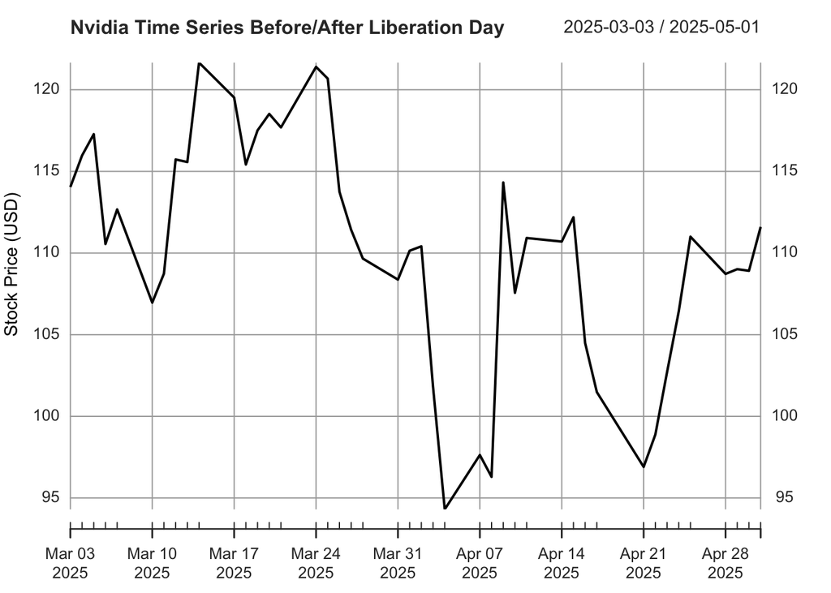

```r
##Nvidia
nvda_data<-tq_get("NVDA",get="stock.prices",complete_cases=TRUE,from="2025-03-02",to="2025-05-02")
xts_nvda<-xts(nvda_data$adjusted,order.by=nvda_data$date)
plot(xts_nvda,main="Nvidia Time Series Before/After Liberation Day",xlab="Date",ylab="Stock Price (USD)")
```

```r
nvda_data
```

```
## # A tibble: 43 × 8
##    symbol date        open  high   low close    volume adjusted
##    <chr>  <date>     <dbl> <dbl> <dbl> <dbl>     <dbl>    <dbl>
##  1 NVDA   2025-03-03  124.  124.  112.  114. 411381400     114.
##  2 NVDA   2025-03-04  111.  119.  110.  116. 398163300     116.
##  3 NVDA   2025-03-05  118.  118.  115.  117. 284337900     117.
##  4 NVDA   2025-03-06  114.  115.  110.  111. 321181900     111.
##  5 NVDA   2025-03-07  111.  113.  108.  113. 341755500     113.
##  6 NVDA   2025-03-10  110.  112.  105.  107. 366487400     107.
##  7 NVDA   2025-03-11  107.  112.  105.  109. 354865700     109.
##  8 NVDA   2025-03-12  114.  117.  113.  116. 323857500     116.
##  9 NVDA   2025-03-13  117.  118.  114.  116. 299033100     116.
## 10 NVDA   2025-03-14  119.  122.  118.  122. 277593500     122.
## # ℹ 33 more rows
```

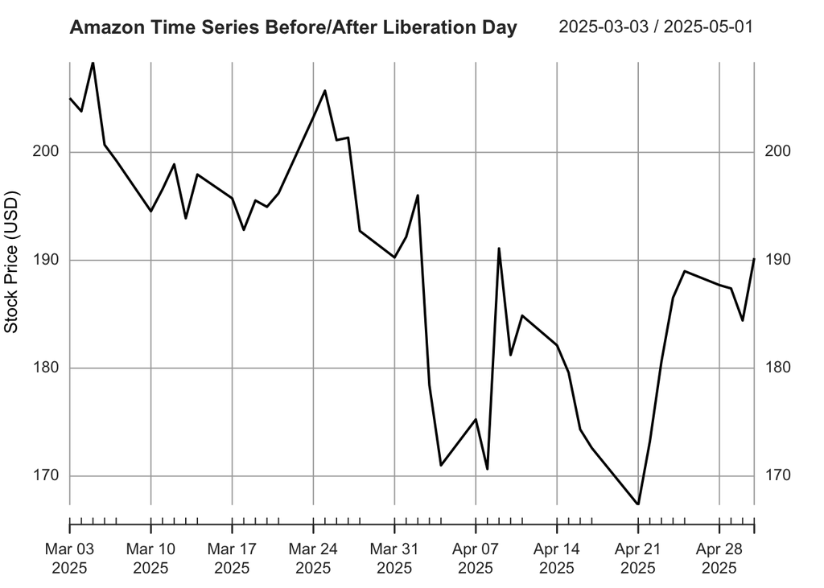

```r
##Amazon
amzn_data<-tq_get("AMZN",get="stock.prices",complete_cases=TRUE,from="2025-03-02",to="2025-05-02")
xts_amzn<-xts(amzn_data$adjusted,order.by=amzn_data$date)
plot(xts_amzn,main="Amazon Time Series Before/After Liberation Day",xlab="Date",ylab="Stock Price (USD)")
```

```r
amzn_data
```

```
## # A tibble: 43 × 8
##    symbol date        open  high   low close   volume adjusted
##    <chr>  <date>     <dbl> <dbl> <dbl> <dbl>    <dbl>    <dbl>
##  1 AMZN   2025-03-03  213.  214.  203.  205. 42948400     205.
##  2 AMZN   2025-03-04  200.  207.  197.  204. 60853100     204.
##  3 AMZN   2025-03-05  205.  210.  203.  208. 38610100     208.
##  4 AMZN   2025-03-06  204.  206.  198.  201. 49863800     201.
##  5 AMZN   2025-03-07  199.  202.  193.  199. 59802800     199.
##  6 AMZN   2025-03-10  196.  197.  191.  195. 62350900     195.
##  7 AMZN   2025-03-11  194.  200.  193.  197. 54002900     197.
##  8 AMZN   2025-03-12  201.  202.  195.  199. 43679300     199.
##  9 AMZN   2025-03-13  198.  199.  192.  194. 41270800     194.
## 10 AMZN   2025-03-14  197.  199.  195.  198. 38096700     198.
## # ℹ 33 more rows
```

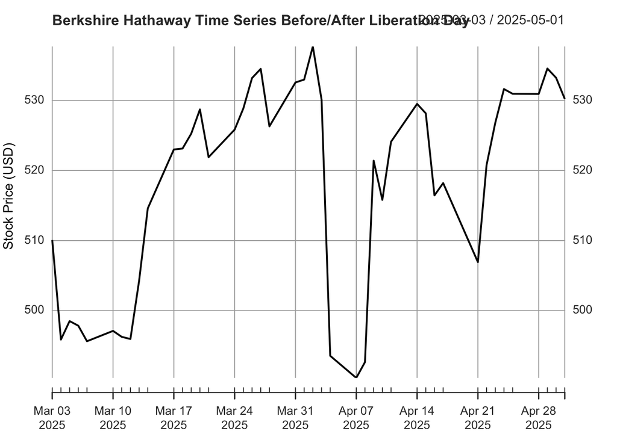

```r
##Berkshire Hathaway

brkb_data<-tq_get("BRK-B",get="stock.prices",complete_cases=TRUE,from="2025-03-02",to="2025-05-02")
xts_brkb<-xts(brkb_data$adjusted,order.by=brkb_data$date)
plot(xts_brkb,main="Berkshire Hathaway Time Series Before/After Liberation Day",xlab="Date",ylab="Stock Price (USD)")
```

```r
brkb_data
```

```
## # A tibble: 43 × 8
##    symbol date        open  high   low close  volume adjusted
##    <chr>  <date>     <dbl> <dbl> <dbl> <dbl>   <dbl>    <dbl>
##  1 BRK-B  2025-03-03  516.  519.  506.  510. 5112300     510.
##  2 BRK-B  2025-03-04  507.  509.  494.  496. 6126600     496.
##  3 BRK-B  2025-03-05  496   501.  492.  498. 4715800     498.
##  4 BRK-B  2025-03-06  497.  499.  492.  498. 3989700     498.
##  5 BRK-B  2025-03-07  496.  498.  490.  496. 3842200     496.
##  6 BRK-B  2025-03-10  490   500.  490   497. 6262000     497.
##  7 BRK-B  2025-03-11  496   499.  491.  496. 5358300     496.
##  8 BRK-B  2025-03-12  498.  498.  489.  496. 3871100     496.
##  9 BRK-B  2025-03-13  496.  507.  495.  504. 5104200     504.
## 10 BRK-B  2025-03-14  507.  516.  503.  515. 5775600     515.
## # ℹ 33 more rows
```

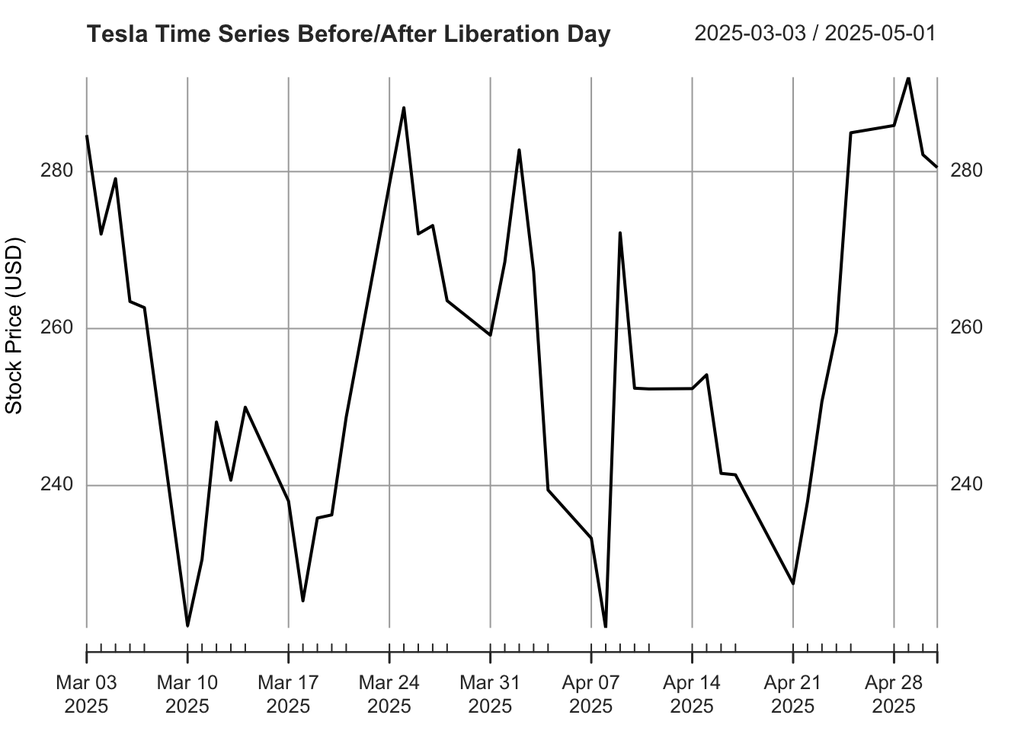

```r
##Tesla

tsla_data<-tq_get("TSLA",get="stock.prices",complete_cases=TRUE,from="2025-03-02",to="2025-05-02")
xts_tsla<-xts(tsla_data$adjusted,order.by=tsla_data$date)
plot(xts_tsla,main="Tesla Time Series Before/After Liberation Day",xlab="Date",ylab="Stock Price (USD)")
```

```r
tsla_data
```

```
## # A tibble: 43 × 8
##    symbol date        open  high   low close    volume adjusted
##    <chr>  <date>     <dbl> <dbl> <dbl> <dbl>     <dbl>    <dbl>
##  1 TSLA   2025-03-03  300.  304.  277.  285. 115551400     285.
##  2 TSLA   2025-03-04  271.  284.  262.  272. 126706600     272.
##  3 TSLA   2025-03-05  273.  280.  268.  279.  94042900     279.
##  4 TSLA   2025-03-06  272.  273.  260.  263.  98451600     263.
##  5 TSLA   2025-03-07  259.  266.  251.  263. 102369600     263.
##  6 TSLA   2025-03-10  253.  253.  220   222. 189076900     222.
##  7 TSLA   2025-03-11  225.  237.  217.  231. 174896400     231.
##  8 TSLA   2025-03-12  247.  252.  241.  248. 142215700     248.
##  9 TSLA   2025-03-13  248.  248.  233.  241. 114813500     241.
## 10 TSLA   2025-03-14  247.  252.  241.  250. 100242300     250.
## # ℹ 33 more rows
```

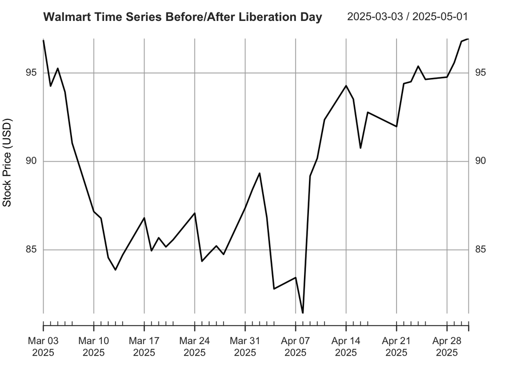

```r
##Walmart

wmt_data<-tq_get("WMT",get="stock.prices",complete_cases=TRUE,from="2025-03-02",to="2025-05-02")
xts_wmt<-xts(wmt_data$adjusted,order.by=tsla_data$date)
plot(xts_wmt,main="Walmart Time Series Before/After Liberation Day",xlab="Date",ylab="Stock Price (USD)")
```

```r
wmt_data
```

```
## # A tibble: 43 × 8
##    symbol date        open  high   low close   volume adjusted
##    <chr>  <date>     <dbl> <dbl> <dbl> <dbl>    <dbl>    <dbl>
##  1 WMT    2025-03-03  98.0  99.5  96.8  97.6 18372200     96.9
##  2 WMT    2025-03-04  95.8  97.1  94.5  95.0 25227700     94.3
##  3 WMT    2025-03-05  95.0  96.4  94.8  96.0 17639000     95.3
##  4 WMT    2025-03-06  94.8  96.2  94.2  94.6 19957800     93.9
##  5 WMT    2025-03-07  93.9  93.9  90.8  91.7 35913200     91.0
##  6 WMT    2025-03-10  89.8  90.2  86.6  87.8 35148800     87.2
##  7 WMT    2025-03-11  87.3  89.3  87.1  87.4 28687600     86.8
##  8 WMT    2025-03-12  87.9  89.1  84.9  85.2 33301600     84.6
##  9 WMT    2025-03-13  84.9  85.4  83.9  84.5 31507800     83.9
## 10 WMT    2025-03-14  85.0  85.4  84.1  85.3 35500600     84.7
## # ℹ 33 more rows
```

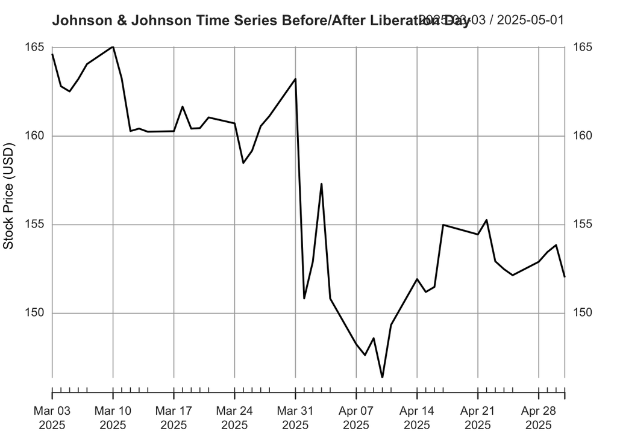

```r
##Johnson & Johnson

jnj_data<-tq_get("JNJ",get="stock.prices",complete_cases=TRUE,from="2025-03-02",to="2025-05-02")
xts_jnj<-xts(jnj_data$adjusted,order.by=tsla_data$date)
plot(xts_jnj,main="Johnson & Johnson Time Series Before/After Liberation Day",xlab="Date",ylab="Stock Price (USD)")
```

```r
jnj_data
```

```
## # A tibble: 43 × 8
##    symbol date        open  high   low close   volume adjusted
##    <chr>  <date>     <dbl> <dbl> <dbl> <dbl>    <dbl>    <dbl>
##  1 JNJ    2025-03-03  165.  167.  165.  167.  9191500     165.
##  2 JNJ    2025-03-04  168.  170.  165.  165. 11999700     163.
##  3 JNJ    2025-03-05  165.  166.  164.  165.  8744800     163.
##  4 JNJ    2025-03-06  165   166.  164.  166.  8037900     163.
##  5 JNJ    2025-03-07  165.  168.  165.  167.  9637600     164.
##  6 JNJ    2025-03-10  167.  170.  167.  168. 17559000     165.
##  7 JNJ    2025-03-11  167.  167.  165.  166.  9890300     163.
##  8 JNJ    2025-03-12  164.  164.  162.  163.  8010700     160.
##  9 JNJ    2025-03-13  163.  165.  163.  163.  5286700     160.
## 10 JNJ    2025-03-14  162.  163.  161.  163.  6235800     160.
## # ℹ 33 more rows
```

## Analysis of Time Series

Amongst all of the selected stocks, stock prices plummeted within 1-2 days around Liberation Day. According to Scotiabank, tariffs may impact several economic factors, including spending and exchange rates, which allows for more uncertainty in global economies. Based on the time series, this suggests that the economic uncertainty resulting from the Liberation Day tariffs has caused stocks to decline steeply. Johnson & Johnson stocks were the only stocks to decline in price a day before Liberation Day. Prices also declined by around 13 USD, a relatively larger decline compared to previous declines. However, this may not necessarily imply that the healthcare sector is more vulnerable to economic uncertainty. On April 1 (the day preceding Liberation Day), a United States judge rejected a $10 billion proposal from Johnson & Johnson to settle a talc litigation. This decision may have caused more uncertainty towards Johnson & Johnson, which may have resulted in the stock price dip observed. Within 2 days after Liberation Day, Tesla stock prices experienced the largest decline out of all stocks in this analysis, while the Johnson & Johnson stock declined the least. This phenomenon is consistent with the observation that it was not necessarily Liberation Day tariffs that caused the declines, as the stock prices dipped by 3 USD. Tesla’s stock price dip may be attributed to its Chief Executive Officer, Elon Musk, who was highly involved in the current United States administration that was responsible for making these tariff decisions. A United States national poll from Marquette University Law School found that 54% of Americans disapproved of Elon Musk. With a low reputation adding to economic uncertainty from tariffs, Tesla’s stock will likely face more severe impacts than companies with less controversial figures.

## Cross Validation for Time Series Trend Decomposition for Liberation Day

```r
set.seed(100)

##Nvidia
nvda_train<-trainControl(method="timeslice",initialWindow=37,horizon=3)
nvda_grid_vals<-expand.grid(span=seq(from=0.1,to=1,by=0.01),degree=1)
nvda_data$date_times<-as.numeric(nvda_data$date)
nvda_cv<-suppressWarnings(train(adjusted~date_times,data=nvda_data,method="gamLoess",tuneGrid=nvda_grid_vals,
                                trControl=nvda_train))
nvda_optimal_span<-nvda_cv$results|>slice_min(RMSE,with_ties=FALSE)|>pull(span)

##Amazon

amzn_train<-trainControl(method="timeslice",initialWindow=37,horizon=3)
amzn_grid_vals<-expand.grid(span=seq(from=0.1,to=1,by=0.01),degree=1)
amzn_data$date_times<-as.numeric(amzn_data$date)
amzn_cv<-suppressWarnings(train(adjusted~date_times,data=amzn_data,method="gamLoess",tuneGrid=amzn_grid_vals,
                                trControl=amzn_train))
amzn_optimal_span<-amzn_cv$results|>slice_min(RMSE,with_ties=FALSE)|>pull(span)

##Berkshire Hathaway

brkb_train<-trainControl(method="timeslice",initialWindow=37,horizon=3)
brkb_grid_vals<-expand.grid(span=seq(from=0.1,to=1,by=0.01),degree=1)
brkb_data$date_times<-as.numeric(brkb_data$date)
brkb_cv<-suppressWarnings(train(adjusted~date_times,data=brkb_data,method="gamLoess",tuneGrid=brkb_grid_vals,
                                trControl=brkb_train))
brkb_optimal_span<-brkb_cv$results|>slice_min(RMSE,with_ties=FALSE)|>pull(span)

##Tesla

tsla_train<-trainControl(method="timeslice",initialWindow=37,horizon=3)
tsla_grid_vals<-expand.grid(span=seq(from=0.1,to=1,by=0.01),degree=1)
tsla_data$date_times<-as.numeric(tsla_data$date)
tsla_cv<-suppressWarnings(train(adjusted~date_times,data=tsla_data,method="gamLoess",tuneGrid=tsla_grid_vals,
                                trControl=tsla_train))
tsla_optimal_span<-tsla_cv$results|>slice_min(RMSE,with_ties=FALSE)|>pull(span)

##Walmart

wmt_train<-trainControl(method="timeslice",initialWindow=37,horizon=3)
wmt_grid_vals<-expand.grid(span=seq(from=0.1,to=1,by=0.01),degree=1)
wmt_data$date_times<-as.numeric(wmt_data$date)
wmt_cv<-suppressWarnings(train(adjusted~date_times,data=wmt_data,method="gamLoess",tuneGrid=wmt_grid_vals,
                               trControl=wmt_train))
wmt_optimal_span<-wmt_cv$results|>slice_min(RMSE,with_ties=FALSE)|>pull(span)

##Johnson & Johnson

jnj_train<-trainControl(method="timeslice",initialWindow=37,horizon=3)
jnj_grid_vals<-expand.grid(span=seq(from=0.1,to=1,by=0.01),degree=1)
jnj_data$date_times<-as.numeric(jnj_data$date)
jnj_cv<-suppressWarnings(train(adjusted~date_times,data=jnj_data,method="gamLoess",tuneGrid=jnj_grid_vals,
                               trControl=jnj_train))
jnj_optimal_span<-jnj_cv$results|>slice_min(RMSE,with_ties=FALSE)|>pull(span)

nvda_optimal_span
```

```
## [1] 0.52
```

```r
amzn_optimal_span
```

```
## [1] 0.3
```

```r
brkb_optimal_span
```

```
## [1] 0.46
```

```r
tsla_optimal_span
```

```
## [1] 0.38
```

```r
wmt_optimal_span
```

```
## [1] 0.82
```

```r
jnj_optimal_span
```

```
## [1] 0.6
```

## Time Series Decomposition (Trend & Residual)

Trend and Residual decompositions are created for the Time Series for Liberation Day of the 6 S&P 500 stocks using the optimal span calculated for each stock. Seasonal decompositions were not included as Liberation Day is a one-time event and does not occur on a seasonal basis.

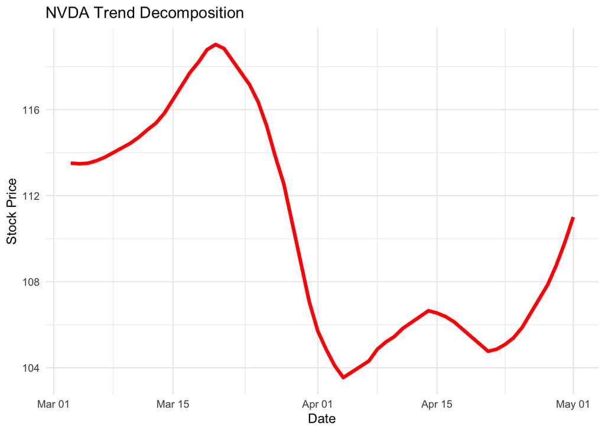

```r
##Nvidia
loess_nvda<-loess(adjusted~as.numeric(date),data=nvda_data,span=nvda_optimal_span)
smooth_nvda<-predict(loess_nvda)
trend_decomp_nvda_plot<-nvda_data|>ggplot(aes(x=date))+geom_line(aes(y=smooth_nvda),color="red",linewidth=1.4) +
                                   labs(title="NVDA Trend Decomposition",x="Date",y="Stock Price")+theme_minimal()
trend_decomp_nvda_plot
```

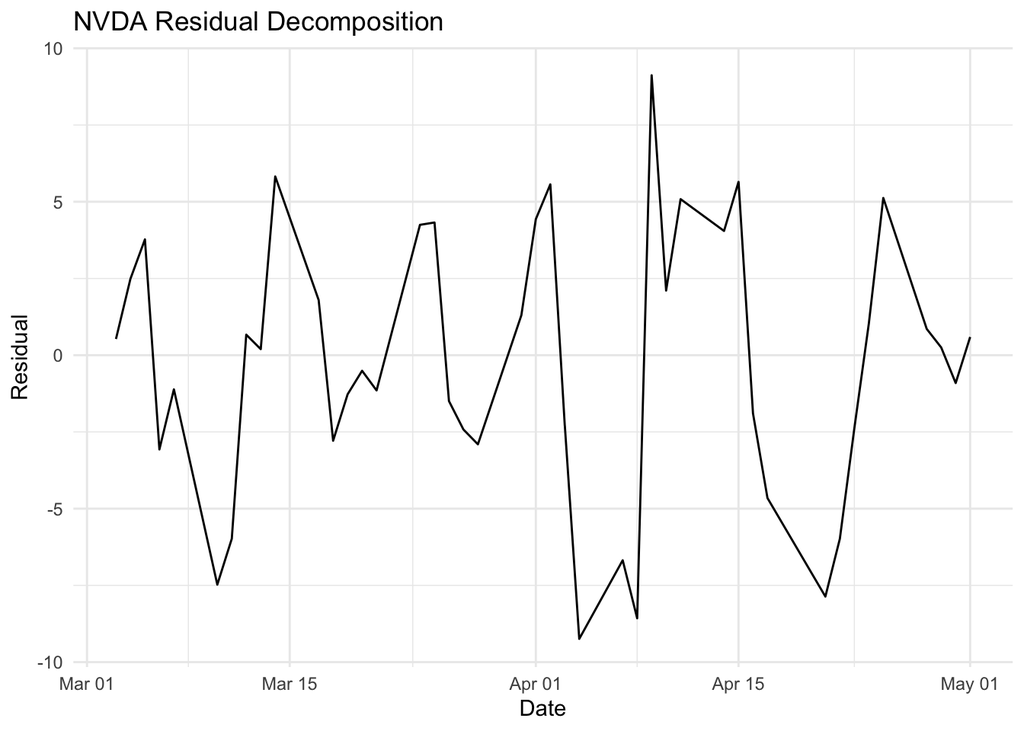

```r
nvda_data$residual_decomp<-residuals(loess_nvda)
residual_decomp_nvda_plot<-nvda_data|>ggplot(aes(x=date,y=residual_decomp))+geom_line() +
                                      labs(title="NVDA Residual Decomposition",x="Date",y="Residual") +
                                      theme_minimal()
residual_decomp_nvda_plot
```

```r
nvda_data
```

```
## # A tibble: 43 × 10
##    symbol date        open  high   low close    volume adjusted date_times
##    <chr>  <date>     <dbl> <dbl> <dbl> <dbl>     <dbl>    <dbl>      <dbl>
##  1 NVDA   2025-03-03  124.  124.  112.  114. 411381400     114.      20150
##  2 NVDA   2025-03-04  111.  119.  110.  116. 398163300     116.      20151
##  3 NVDA   2025-03-05  118.  118.  115.  117. 284337900     117.      20152
##  4 NVDA   2025-03-06  114.  115.  110.  111. 321181900     111.      20153
##  5 NVDA   2025-03-07  111.  113.  108.  113. 341755500     113.      20154
##  6 NVDA   2025-03-10  110.  112.  105.  107. 366487400     107.      20157
##  7 NVDA   2025-03-11  107.  112.  105.  109. 354865700     109.      20158
##  8 NVDA   2025-03-12  114.  117.  113.  116. 323857500     116.      20159
##  9 NVDA   2025-03-13  117.  118.  114.  116. 299033100     116.      20160
## 10 NVDA   2025-03-14  119.  122.  118.  122. 277593500     122.      20161
## # ℹ 33 more rows
## # ℹ 1 more variable: residual_decomp <dbl>
```

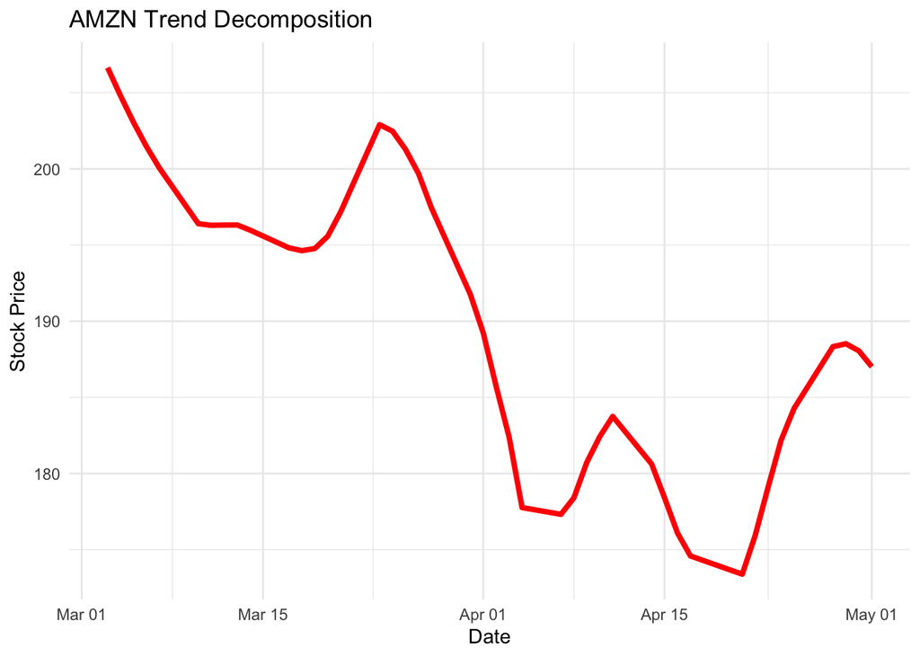

```r
##Amazon
loess_amzn<-loess(adjusted~as.numeric(date),data=amzn_data,span=amzn_optimal_span)
smooth_amzn<-predict(loess_amzn)
trend_decomp_amzn_plot<-amzn_data|>ggplot(aes(x=date))+geom_line(aes(y=smooth_amzn),color="red",linewidth=1.4) +
                                   labs(title="AMZN Trend Decomposition",x="Date",y="Stock Price") +
                                   theme_minimal()
trend_decomp_amzn_plot
```

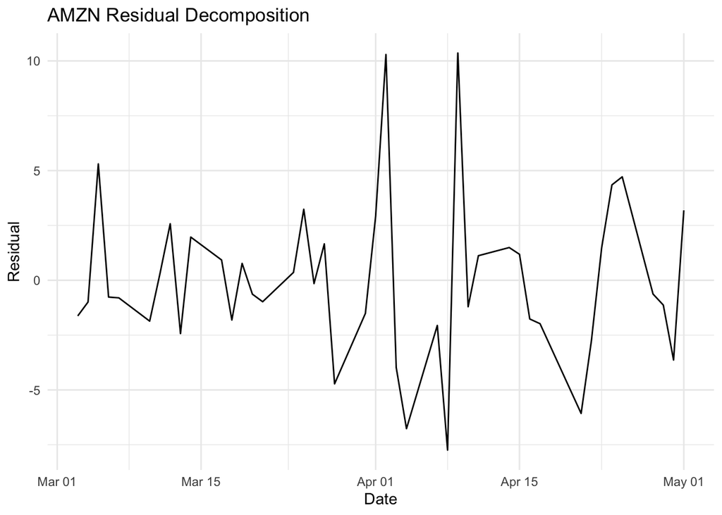

```r
amzn_data$residual_decomp<-residuals(loess_amzn)
residual_decomp_amzn_plot<-amzn_data|>ggplot(aes(x=date,y=residual_decomp))+geom_line() +
                                      labs(title="AMZN Residual Decomposition",x="Date",y="Residual") +
                                      theme_minimal()
residual_decomp_amzn_plot
```

```r
amzn_data
```

```
## # A tibble: 43 × 10
##    symbol date        open  high   low close   volume adjusted date_times
##    <chr>  <date>     <dbl> <dbl> <dbl> <dbl>    <dbl>    <dbl>      <dbl>
##  1 AMZN   2025-03-03  213.  214.  203.  205. 42948400     205.      20150
##  2 AMZN   2025-03-04  200.  207.  197.  204. 60853100     204.      20151
##  3 AMZN   2025-03-05  205.  210.  203.  208. 38610100     208.      20152
##  4 AMZN   2025-03-06  204.  206.  198.  201. 49863800     201.      20153
##  5 AMZN   2025-03-07  199.  202.  193.  199. 59802800     199.      20154
##  6 AMZN   2025-03-10  196.  197.  191.  195. 62350900     195.      20157
##  7 AMZN   2025-03-11  194.  200.  193.  197. 54002900     197.      20158
##  8 AMZN   2025-03-12  201.  202.  195.  199. 43679300     199.      20159
##  9 AMZN   2025-03-13  198.  199.  192.  194. 41270800     194.      20160
## 10 AMZN   2025-03-14  197.  199.  195.  198. 38096700     198.      20161
## # ℹ 33 more rows
## # ℹ 1 more variable: residual_decomp <dbl>
```

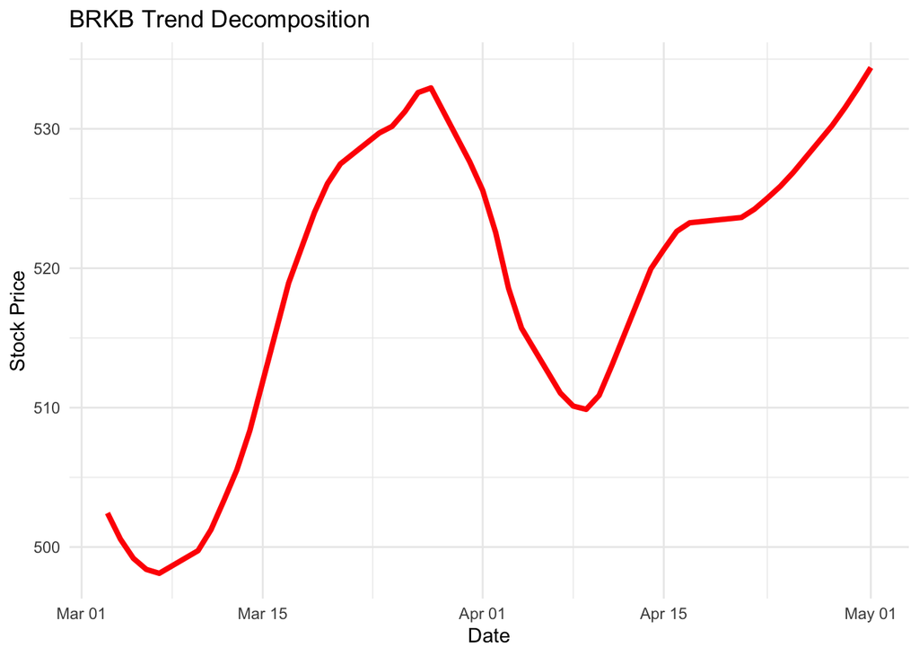

```r
##Berkshire Hathaway
loess_brkb<-loess(adjusted~as.numeric(date),data=brkb_data,span=brkb_optimal_span)
smooth_brkb<-predict(loess_brkb)
trend_decomp_brkb_plot<-brkb_data|>ggplot(aes(x=date))+geom_line(aes(y=smooth_brkb),color="red",linewidth=1.4) +
                                   labs(title="BRKB Trend Decomposition",x="Date",y="Stock Price") +
                                   theme_minimal()
trend_decomp_brkb_plot
```

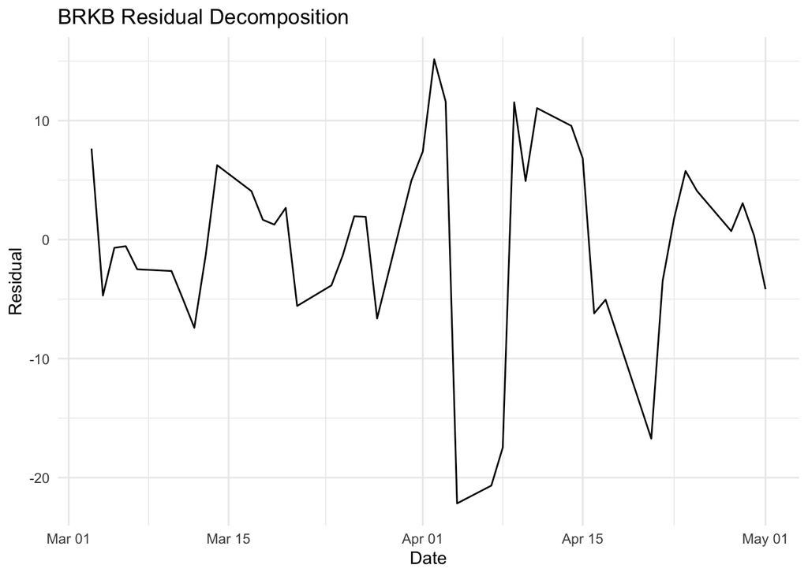

```r
brkb_data$residual_decomp<-residuals(loess_brkb)
residual_decomp_brkb_plot<-brkb_data|>ggplot(aes(x=date,y=residual_decomp))+geom_line() +
                                      labs(title="BRKB Residual Decomposition",x="Date",y="Residual") +
                                      theme_minimal()
residual_decomp_brkb_plot
```

```r
brkb_data
```

```
## # A tibble: 43 × 10
##    symbol date        open  high   low close  volume adjusted date_times
##    <chr>  <date>     <dbl> <dbl> <dbl> <dbl>   <dbl>    <dbl>      <dbl>
##  1 BRK-B  2025-03-03  516.  519.  506.  510. 5112300     510.      20150
##  2 BRK-B  2025-03-04  507.  509.  494.  496. 6126600     496.      20151
##  3 BRK-B  2025-03-05  496   501.  492.  498. 4715800     498.      20152
##  4 BRK-B  2025-03-06  497.  499.  492.  498. 3989700     498.      20153
##  5 BRK-B  2025-03-07  496.  498.  490.  496. 3842200     496.      20154
##  6 BRK-B  2025-03-10  490   500.  490   497. 6262000     497.      20157
##  7 BRK-B  2025-03-11  496   499.  491.  496. 5358300     496.      20158
##  8 BRK-B  2025-03-12  498.  498.  489.  496. 3871100     496.      20159
##  9 BRK-B  2025-03-13  496.  507.  495.  504. 5104200     504.      20160
## 10 BRK-B  2025-03-14  507.  516.  503.  515. 5775600     515.      20161
## # ℹ 33 more rows
## # ℹ 1 more variable: residual_decomp <dbl>
```

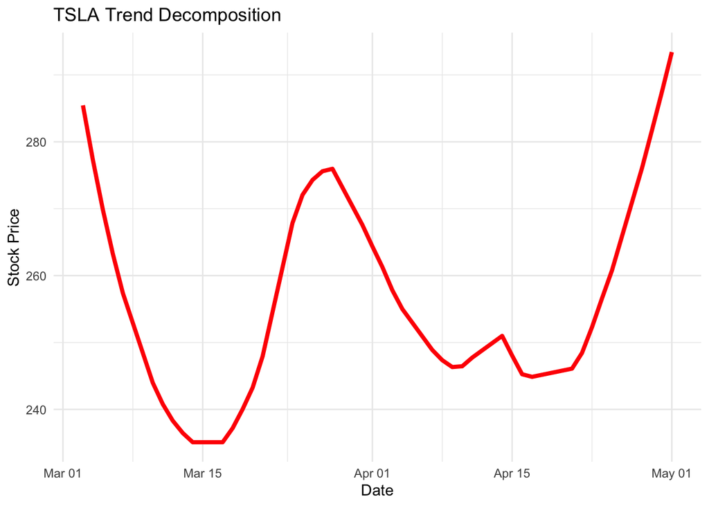

```r
##Tesla
loess_tsla<-loess(adjusted~as.numeric(date),data=tsla_data,span=tsla_optimal_span)
smooth_tsla<-predict(loess_tsla)
trend_decomp_tsla_plot<-tsla_data|>ggplot(aes(x=date))+geom_line(aes(y=smooth_tsla),color="red",linewidth=1.4) +
                                   labs(title="TSLA Trend Decomposition",x="Date",y="Stock Price") +
                                   theme_minimal()
trend_decomp_tsla_plot
```

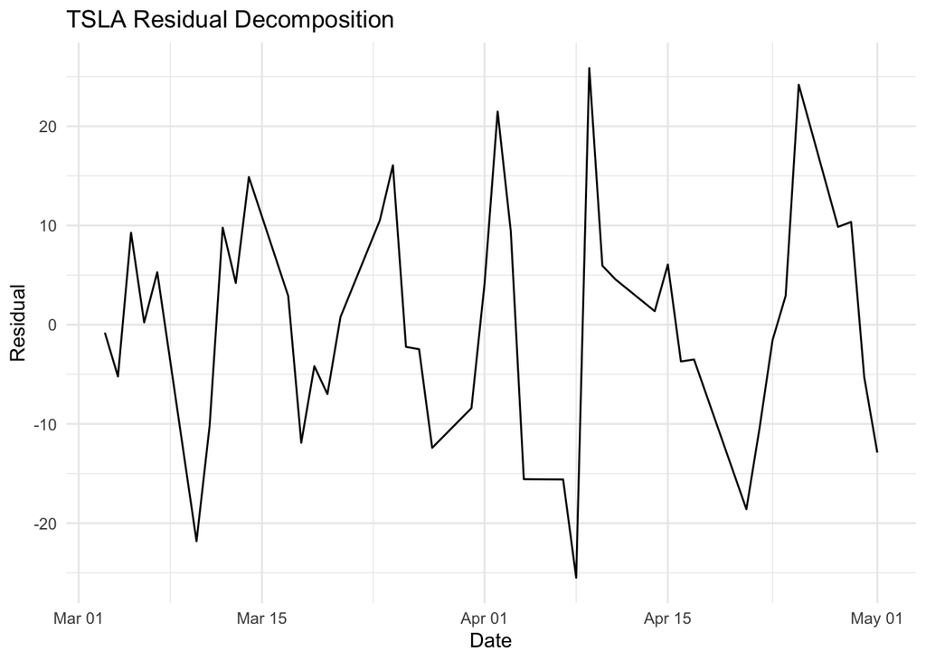

```r
tsla_data$residual_decomp<-residuals(loess_tsla)
residual_decomp_tsla_plot<-tsla_data|>ggplot(aes(x=date,y=residual_decomp))+geom_line() +
                                      labs(title="TSLA Residual Decomposition",x="Date",y="Residual") +
                                      theme_minimal()
residual_decomp_tsla_plot
```

```r
tsla_data
```

```
## # A tibble: 43 × 10
##    symbol date        open  high   low close    volume adjusted date_times
##    <chr>  <date>     <dbl> <dbl> <dbl> <dbl>     <dbl>    <dbl>      <dbl>
##  1 TSLA   2025-03-03  300.  304.  277.  285. 115551400     285.      20150
##  2 TSLA   2025-03-04  271.  284.  262.  272. 126706600     272.      20151
##  3 TSLA   2025-03-05  273.  280.  268.  279.  94042900     279.      20152
##  4 TSLA   2025-03-06  272.  273.  260.  263.  98451600     263.      20153
##  5 TSLA   2025-03-07  259.  266.  251.  263. 102369600     263.      20154
##  6 TSLA   2025-03-10  253.  253.  220   222. 189076900     222.      20157
##  7 TSLA   2025-03-11  225.  237.  217.  231. 174896400     231.      20158
##  8 TSLA   2025-03-12  247.  252.  241.  248. 142215700     248.      20159
##  9 TSLA   2025-03-13  248.  248.  233.  241. 114813500     241.      20160
## 10 TSLA   2025-03-14  247.  252.  241.  250. 100242300     250.      20161
## # ℹ 33 more rows
## # ℹ 1 more variable: residual_decomp <dbl>
```

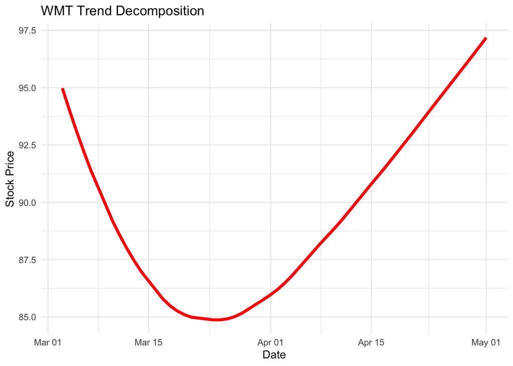

```r
##Walmart

loess_wmt<-loess(adjusted~as.numeric(date),data=wmt_data,span=wmt_optimal_span)
smooth_wmt<-predict(loess_wmt)
trend_decomp_wmt_plot<-wmt_data|>ggplot(aes(x=date))+geom_line(aes(y=smooth_wmt),color="red",linewidth=1.4) +
                                 labs(title="WMT Trend Decomposition",x="Date",y="Stock Price") +
                                 theme_minimal()
trend_decomp_wmt_plot
```

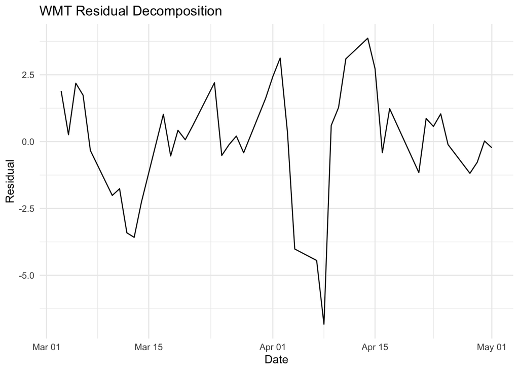

```r
wmt_data$residual_decomp<-residuals(loess_wmt)
residual_decomp_wmt_plot<-wmt_data|>ggplot(aes(x=date,y=residual_decomp))+geom_line() +
                                    labs(title="WMT Residual Decomposition",x="Date",y="Residual") +
                                    theme_minimal()
residual_decomp_wmt_plot
```

```r
wmt_data
```

```
## # A tibble: 43 × 10
##    symbol date        open  high   low close   volume adjusted date_times
##    <chr>  <date>     <dbl> <dbl> <dbl> <dbl>    <dbl>    <dbl>      <dbl>
##  1 WMT    2025-03-03  98.0  99.5  96.8  97.6 18372200     96.9      20150
##  2 WMT    2025-03-04  95.8  97.1  94.5  95.0 25227700     94.3      20151
##  3 WMT    2025-03-05  95.0  96.4  94.8  96.0 17639000     95.3      20152
##  4 WMT    2025-03-06  94.8  96.2  94.2  94.6 19957800     93.9      20153
##  5 WMT    2025-03-07  93.9  93.9  90.8  91.7 35913200     91.0      20154
##  6 WMT    2025-03-10  89.8  90.2  86.6  87.8 35148800     87.2      20157
##  7 WMT    2025-03-11  87.3  89.3  87.1  87.4 28687600     86.8      20158
##  8 WMT    2025-03-12  87.9  89.1  84.9  85.2 33301600     84.6      20159
##  9 WMT    2025-03-13  84.9  85.4  83.9  84.5 31507800     83.9      20160
## 10 WMT    2025-03-14  85.0  85.4  84.1  85.3 35500600     84.7      20161
## # ℹ 33 more rows
## # ℹ 1 more variable: residual_decomp <dbl>
```

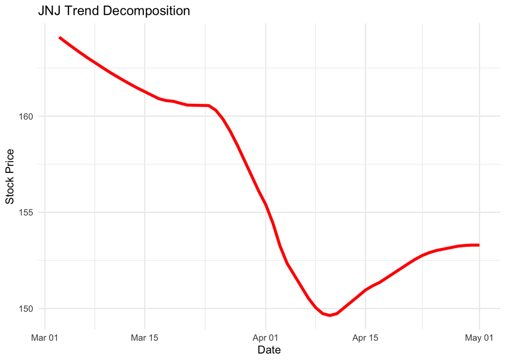

```r
##Johnson & Johnson

loess_jnj<-loess(adjusted~as.numeric(date),data=jnj_data,span=jnj_optimal_span)
smooth_jnj<-predict(loess_jnj)
trend_decomp_jnj_plot<-jnj_data|>ggplot(aes(x=date))+geom_line(aes(y=smooth_jnj),color="red",linewidth=1.4) +
                                 labs(title="JNJ Trend Decomposition",x="Date",y="Stock Price") +
                                 theme_minimal()
trend_decomp_jnj_plot
```

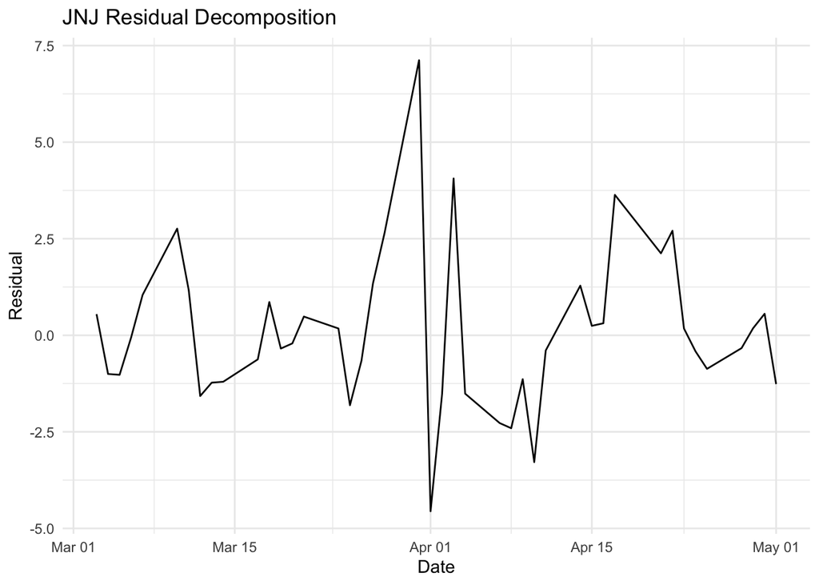

```r
jnj_data$residual_decomp<-residuals(loess_jnj)
residual_decomp_jnj_plot<-jnj_data|>ggplot(aes(x=date,y=residual_decomp))+geom_line() +
                                    labs(title="JNJ Residual Decomposition",x="Date",y="Residual") +
                                    theme_minimal()
residual_decomp_jnj_plot
```

```r
jnj_data
```

```
## # A tibble: 43 × 10
##    symbol date        open  high   low close   volume adjusted date_times
##    <chr>  <date>     <dbl> <dbl> <dbl> <dbl>    <dbl>    <dbl>      <dbl>
##  1 JNJ    2025-03-03  165.  167.  165.  167.  9191500     165.      20150
##  2 JNJ    2025-03-04  168.  170.  165.  165. 11999700     163.      20151
##  3 JNJ    2025-03-05  165.  166.  164.  165.  8744800     163.      20152
##  4 JNJ    2025-03-06  165   166.  164.  166.  8037900     163.      20153
##  5 JNJ    2025-03-07  165.  168.  165.  167.  9637600     164.      20154
##  6 JNJ    2025-03-10  167.  170.  167.  168. 17559000     165.      20157
##  7 JNJ    2025-03-11  167.  167.  165.  166.  9890300     163.      20158
##  8 JNJ    2025-03-12  164.  164.  162.  163.  8010700     160.      20159
##  9 JNJ    2025-03-13  163.  165.  163.  163.  5286700     160.      20160
## 10 JNJ    2025-03-14  162.  163.  161.  163.  6235800     160.      20161
## # ℹ 33 more rows
## # ℹ 1 more variable: residual_decomp <dbl>
```

## Analysis of Trend and Residual Decompositions

Amongst all stocks, the trend estimates indicate that approximately a month after Liberation Day, stock prices are recovering again and remaining above the low prices observed within 2 days of Liberation Day. Despite Tesla’s stock price declining the most within 2 days, Tesla’s residual value on Liberation Day was approximately 21 USD, the highest of all the stocks on that day. Elon Musk opposed the tariffs, which may be associated with Tesla avoiding a larger decline in stock prices, based on the residual observed and how stock prices have dipped dramatically after the announcement. All stocks experienced larger than usual one-day residual changes from April 8 to April 9 (day of tariff pause) compared to most other one-day changes within the 43 trading days. In fact, except for Johnson & Johnson, all stocks had a greater absolute daily price change from April 8 to April 9 than from April 2 to April 3. This pattern is consistent with stock prices responding more strongly to reductions in uncertainty than to increases in uncertainty. Since Johnson & Johnson did not experience as large an impact on their stock prices, it may imply that Liberation Day tariffs do not appear to have substantially affected its market valuation. Furthermore, since Johnson & Johnson is one of the largest health care companies in the S&P 500, this phenomenon may also suggest that the Health Care sector is less sensitive to economic uncertainties caused by tariffs.

## Returns, Mean Returns, Volatility, and 3-Day Rolling Volatility

Calculating returns, mean returns, volatility, and 3-day rolling volatility to compare for data analysis. For each stock, the returns, mean returns, and volatility are calculated prior to and after Liberation Day to observe differences. The 3-day rolling volatility is calculated using the data from the previous 2 trading days and the current day, which means the first 3-day rolling volatility occurs on the third trading day.

```r
###Returns, Mean Returns

##Nvidia
nvda_data<-nvda_data|>mutate(returns=(adjusted-lag(adjusted))/lag(adjusted),
                             mean_returns=if_else(is.na(returns),NA_real_,cummean(replace_na(returns,0))))
nvda_mean_return_pre<-nvda_data|>filter(date<="2025-04-01",date>="2025-03-02")|>
                                 summarise(nvda_mean_return_pre = mean(returns,na.rm=TRUE))
nvda_mean_return_post<-nvda_data|>filter(date>="2025-04-03",date<="2025-05-02")|>
                                  summarise(nvda_mean_return_post = mean(returns,na.rm=TRUE))

##Amazon
amzn_data<-amzn_data|>mutate(returns=(adjusted-lag(adjusted))/lag(adjusted),
                             mean_returns=if_else(is.na(returns),NA_real_,cummean(replace_na(returns,0))))
amzn_mean_return_pre<-amzn_data|>filter(date<="2025-04-01",date>="2025-03-02")|>
                                 summarise(amzn_mean_return_pre = mean(returns,na.rm=TRUE))
amzn_mean_return_post<-nvda_data|>filter(date>="2025-04-03",date<="2025-05-02")|>
                                  summarise(amzn_mean_return_post = mean(returns,na.rm=TRUE))

##Berkshire Hathaway
brkb_data<-brkb_data|>mutate(returns=(adjusted-lag(adjusted))/lag(adjusted),
                             mean_returns=if_else(is.na(returns),NA_real_,cummean(replace_na(returns,0))))
brkb_mean_return_pre<-brkb_data|>filter("2025-03-02"<=date,date<="2025-04-01")|>
                                 summarise(brkb_mean_return_pre=mean(returns,na.rm=TRUE))
brkb_mean_return_post<-brkb_data|>filter("2025-04-03"<=date,date<="2025-05-02")|>
                                  summarise(brkb_mean_return_post=mean(returns,na.rm=TRUE))

##Tesla
tsla_data<-tsla_data|>mutate(returns=(adjusted-lag(adjusted))/lag(adjusted),
                             mean_returns=if_else(is.na(returns),NA_real_,cummean(replace_na(returns,0))))
tsla_mean_return_pre<-tsla_data|>filter("2025-03-02"<=date,date<="2025-04-01")|>
                                 summarise(tsla_mean_return_pre=mean(returns,na.rm=TRUE))
tsla_mean_return_post<-tsla_data|>filter("2025-04-03"<=date,date<="2025-05-02")|>
                                  summarise(tsla_mean_return_post=mean(returns,na.rm=TRUE))

##Walmart
wmt_data<-wmt_data|>mutate(returns=(adjusted-lag(adjusted))/lag(adjusted),
                           mean_returns=if_else(is.na(returns),NA_real_,cummean(replace_na(returns,0))))
wmt_mean_return_pre<-wmt_data|>filter("2025-03-02"<=date,date<="2025-04-01")|>
                               summarise(wmt_mean_return_pre=mean(returns,na.rm=TRUE))
wmt_mean_return_post<-wmt_data|>filter("2025-04-03"<=date,date<="2025-05-02")|>
                                summarise(wmt_mean_return_post=mean(returns,na.rm=TRUE))

##Johnson & Johnson
jnj_data<-jnj_data|>mutate(returns=(adjusted-lag(adjusted))/lag(adjusted),
                           mean_returns=if_else(is.na(returns),NA_real_,cummean(replace_na(returns,0))))
jnj_mean_return_pre<-jnj_data|>filter("2025-03-02"<=date,date<="2025-04-01")|>
                               summarise(jnj_mean_return_pre=mean(returns,na.rm=TRUE))
jnj_mean_return_post<-jnj_data|>filter("2025-04-03"<=date,date<="2025-05-02")|>
                                summarise(jnj_mean_return_post=mean(returns,na.rm=TRUE))


###Volatility

##Nvidia
nvda_volatility<-nvda_data|>summarise(nvda_volatility=sd(returns,na.rm=TRUE))
nvda_volatility_pre<-nvda_data|>filter(date<="2025-04-01",date>="2025-03-02")|>
                                summarise(nvda_volatility_pre=sd(returns,na.rm=TRUE))
nvda_volatility_post<-nvda_data|>filter(date<="2025-05-02",date>="2025-04-03")|>
                                 summarise(nvda_volatility_post=sd(returns,na.rm=TRUE))
nvda_volatility_post
```

```
## # A tibble: 1 × 1
##   nvda_volatility_post
##                  <dbl>
## 1               0.0591
```

```r
##Amazon
amzn_volatility<-amzn_data|>summarise(amzn_volatility=sd(returns,na.rm=TRUE))
amzn_volatility_pre<-amzn_data|>filter(date<="2025-04-01",date>="2025-03-02")|>
                                summarise(amzn_volatility_pre=sd(returns,na.rm=TRUE))
amzn_volatility_post<-amzn_data|>filter(date<="2025-05-02",date>="2025-04-03")|>
                                 summarise(amzn_volatility_post=sd(returns,na.rm=TRUE))

##Berkshire Hathaway
brkb_volatility<-brkb_data|>summarise(brkb_volatility=sd(returns,na.rm=TRUE))
brkb_volatility_pre<-brkb_data|>filter(date<="2025-04-01",date>="2025-03-02")|>
                                summarise(brkb_volatility_pre=sd(returns,na.rm=TRUE))
brkb_volatility_post<-brkb_data|>filter(date<="2025-05-02",date>="2025-04-03")|>
                                 summarise(brkb_volatility_post=sd(returns,na.rm=TRUE))

##Tesla
tsla_volatility<-tsla_data|>summarise(volatility=sd(returns,na.rm=TRUE))
tsla_volatility_pre<-tsla_data|>filter(date<="2025-04-01",date>="2025-03-02")|>
                                summarise(tsla_volatility_pre=sd(returns,na.rm=TRUE))
tsla_volatility_post<-tsla_data|>filter(date<="2025-05-02",date>="2025-04-03")|>
                                 summarise(tsla_volatility_post=sd(returns,na.rm=TRUE))
tsla_volatility_post
```

```
## # A tibble: 1 × 1
##   tsla_volatility_post
##                  <dbl>
## 1               0.0714
```

```r
##Walmart
wmt_volatility<-wmt_data|>summarise(volatility=sd(returns,na.rm=TRUE))
wmt_volatility_pre<-wmt_data|>filter(date<="2025-04-01",date>="2025-03-02")|>
                              summarise(wmt_volatility_pre=sd(returns,na.rm=TRUE))
wmt_volatility_post<-wmt_data|>filter(date<="2025-05-02",date>="2025-04-03")|>
                               summarise(wmt_volatility_post=sd(returns,na.rm=TRUE))
wmt_volatility_post
```

```
## # A tibble: 1 × 1
##   wmt_volatility_post
##                 <dbl>
## 1              0.0291
```

```r
##Johnson & Johnson
jnj_volatility<-jnj_data|>summarise(volatility=sd(returns,na.rm=TRUE))
jnj_volatility_pre<-jnj_data|>filter(date<="2025-04-01",date>="2025-03-02")|>
                              summarise(jnj_volatility_pre=sd(returns,na.rm=TRUE))
jnj_volatility_post<-jnj_data|>filter(date<="2025-05-02",date>="2025-04-03")|>
                               summarise(jnj_volatility_post=sd(returns,na.rm=TRUE))
jnj_volatility_post
```

```
## # A tibble: 1 × 1
##   jnj_volatility_post
##                 <dbl>
## 1              0.0160
```

```r
###3-Day Rolling Volatility

##Nvidia
nvda_data<-nvda_data|>mutate(three_day_rolling_volatility=rollapply(returns,width=3,
                                                                    FUN=sd,na.rm=TRUE,
                                                                    fill=NA,align="right"))
nvda_data
```

```
## # A tibble: 43 × 13
##    symbol date        open  high   low close    volume adjusted date_times
##    <chr>  <date>     <dbl> <dbl> <dbl> <dbl>     <dbl>    <dbl>      <dbl>
##  1 NVDA   2025-03-03  124.  124.  112.  114. 411381400     114.      20150
##  2 NVDA   2025-03-04  111.  119.  110.  116. 398163300     116.      20151
##  3 NVDA   2025-03-05  118.  118.  115.  117. 284337900     117.      20152
##  4 NVDA   2025-03-06  114.  115.  110.  111. 321181900     111.      20153
##  5 NVDA   2025-03-07  111.  113.  108.  113. 341755500     113.      20154
##  6 NVDA   2025-03-10  110.  112.  105.  107. 366487400     107.      20157
##  7 NVDA   2025-03-11  107.  112.  105.  109. 354865700     109.      20158
##  8 NVDA   2025-03-12  114.  117.  113.  116. 323857500     116.      20159
##  9 NVDA   2025-03-13  117.  118.  114.  116. 299033100     116.      20160
## 10 NVDA   2025-03-14  119.  122.  118.  122. 277593500     122.      20161
## # ℹ 33 more rows
## # ℹ 4 more variables: residual_decomp <dbl>, returns <dbl>, mean_returns <dbl>,
## #   three_day_rolling_volatility <dbl>
```

```r
##Amazon
amzn_data<-amzn_data|>mutate(three_day_rolling_volatility=rollapply(returns,width=3,
                                                                    FUN=sd,na.rm=TRUE,
                                                                    fill=NA,align="right"))
amzn_data
```

```
## # A tibble: 43 × 13
##    symbol date        open  high   low close   volume adjusted date_times
##    <chr>  <date>     <dbl> <dbl> <dbl> <dbl>    <dbl>    <dbl>      <dbl>
##  1 AMZN   2025-03-03  213.  214.  203.  205. 42948400     205.      20150
##  2 AMZN   2025-03-04  200.  207.  197.  204. 60853100     204.      20151
##  3 AMZN   2025-03-05  205.  210.  203.  208. 38610100     208.      20152
##  4 AMZN   2025-03-06  204.  206.  198.  201. 49863800     201.      20153
##  5 AMZN   2025-03-07  199.  202.  193.  199. 59802800     199.      20154
##  6 AMZN   2025-03-10  196.  197.  191.  195. 62350900     195.      20157
##  7 AMZN   2025-03-11  194.  200.  193.  197. 54002900     197.      20158
##  8 AMZN   2025-03-12  201.  202.  195.  199. 43679300     199.      20159
##  9 AMZN   2025-03-13  198.  199.  192.  194. 41270800     194.      20160
## 10 AMZN   2025-03-14  197.  199.  195.  198. 38096700     198.      20161
## # ℹ 33 more rows
## # ℹ 4 more variables: residual_decomp <dbl>, returns <dbl>, mean_returns <dbl>,
## #   three_day_rolling_volatility <dbl>
```

```r
##Berkshire Hathaway
brkb_data<-brkb_data|>mutate(three_day_rolling_volatility=rollapply(returns,width=3,
                                                                    FUN=sd,na.rm=TRUE,
                                                                    fill=NA,align="right"))
brkb_data
```

```
## # A tibble: 43 × 13
##    symbol date        open  high   low close  volume adjusted date_times
##    <chr>  <date>     <dbl> <dbl> <dbl> <dbl>   <dbl>    <dbl>      <dbl>
##  1 BRK-B  2025-03-03  516.  519.  506.  510. 5112300     510.      20150
##  2 BRK-B  2025-03-04  507.  509.  494.  496. 6126600     496.      20151
##  3 BRK-B  2025-03-05  496   501.  492.  498. 4715800     498.      20152
##  4 BRK-B  2025-03-06  497.  499.  492.  498. 3989700     498.      20153
##  5 BRK-B  2025-03-07  496.  498.  490.  496. 3842200     496.      20154
##  6 BRK-B  2025-03-10  490   500.  490   497. 6262000     497.      20157
##  7 BRK-B  2025-03-11  496   499.  491.  496. 5358300     496.      20158
##  8 BRK-B  2025-03-12  498.  498.  489.  496. 3871100     496.      20159
##  9 BRK-B  2025-03-13  496.  507.  495.  504. 5104200     504.      20160
## 10 BRK-B  2025-03-14  507.  516.  503.  515. 5775600     515.      20161
## # ℹ 33 more rows
## # ℹ 4 more variables: residual_decomp <dbl>, returns <dbl>, mean_returns <dbl>,
## #   three_day_rolling_volatility <dbl>
```

```r
##Tesla
tsla_data<-tsla_data|>mutate(three_day_rolling_volatility=rollapply(returns,width=3,
                                                                    FUN=sd,na.rm=TRUE,
                                                                    fill=NA,align="right"))
tsla_data
```

```
## # A tibble: 43 × 13
##    symbol date        open  high   low close    volume adjusted date_times
##    <chr>  <date>     <dbl> <dbl> <dbl> <dbl>     <dbl>    <dbl>      <dbl>
##  1 TSLA   2025-03-03  300.  304.  277.  285. 115551400     285.      20150
##  2 TSLA   2025-03-04  271.  284.  262.  272. 126706600     272.      20151
##  3 TSLA   2025-03-05  273.  280.  268.  279.  94042900     279.      20152
##  4 TSLA   2025-03-06  272.  273.  260.  263.  98451600     263.      20153
##  5 TSLA   2025-03-07  259.  266.  251.  263. 102369600     263.      20154
##  6 TSLA   2025-03-10  253.  253.  220   222. 189076900     222.      20157
##  7 TSLA   2025-03-11  225.  237.  217.  231. 174896400     231.      20158
##  8 TSLA   2025-03-12  247.  252.  241.  248. 142215700     248.      20159
##  9 TSLA   2025-03-13  248.  248.  233.  241. 114813500     241.      20160
## 10 TSLA   2025-03-14  247.  252.  241.  250. 100242300     250.      20161
## # ℹ 33 more rows
## # ℹ 4 more variables: residual_decomp <dbl>, returns <dbl>, mean_returns <dbl>,
## #   three_day_rolling_volatility <dbl>
```

```r
##Walmart
wmt_data<-wmt_data|>mutate(three_day_rolling_volatility=rollapply(returns,width=3,
                                                                  FUN=sd,na.rm=TRUE,
                                                                  fill=NA,align="right"))
wmt_data
```

```
## # A tibble: 43 × 13
##    symbol date        open  high   low close   volume adjusted date_times
##    <chr>  <date>     <dbl> <dbl> <dbl> <dbl>    <dbl>    <dbl>      <dbl>
##  1 WMT    2025-03-03  98.0  99.5  96.8  97.6 18372200     96.9      20150
##  2 WMT    2025-03-04  95.8  97.1  94.5  95.0 25227700     94.3      20151
##  3 WMT    2025-03-05  95.0  96.4  94.8  96.0 17639000     95.3      20152
##  4 WMT    2025-03-06  94.8  96.2  94.2  94.6 19957800     93.9      20153
##  5 WMT    2025-03-07  93.9  93.9  90.8  91.7 35913200     91.0      20154
##  6 WMT    2025-03-10  89.8  90.2  86.6  87.8 35148800     87.2      20157
##  7 WMT    2025-03-11  87.3  89.3  87.1  87.4 28687600     86.8      20158
##  8 WMT    2025-03-12  87.9  89.1  84.9  85.2 33301600     84.6      20159
##  9 WMT    2025-03-13  84.9  85.4  83.9  84.5 31507800     83.9      20160
## 10 WMT    2025-03-14  85.0  85.4  84.1  85.3 35500600     84.7      20161
## # ℹ 33 more rows
## # ℹ 4 more variables: residual_decomp <dbl>, returns <dbl>, mean_returns <dbl>,
## #   three_day_rolling_volatility <dbl>
```

```r
##Johnson & Johnson
jnj_data<-jnj_data|>mutate(three_day_rolling_volatility=rollapply(returns,width=3,
                                                                  FUN=sd,na.rm=TRUE,
                                                                  fill=NA,align="right"))
jnj_data
```

```
## # A tibble: 43 × 13
##    symbol date        open  high   low close   volume adjusted date_times
##    <chr>  <date>     <dbl> <dbl> <dbl> <dbl>    <dbl>    <dbl>      <dbl>
##  1 JNJ    2025-03-03  165.  167.  165.  167.  9191500     165.      20150
##  2 JNJ    2025-03-04  168.  170.  165.  165. 11999700     163.      20151
##  3 JNJ    2025-03-05  165.  166.  164.  165.  8744800     163.      20152
##  4 JNJ    2025-03-06  165   166.  164.  166.  8037900     163.      20153
##  5 JNJ    2025-03-07  165.  168.  165.  167.  9637600     164.      20154
##  6 JNJ    2025-03-10  167.  170.  167.  168. 17559000     165.      20157
##  7 JNJ    2025-03-11  167.  167.  165.  166.  9890300     163.      20158
##  8 JNJ    2025-03-12  164.  164.  162.  163.  8010700     160.      20159
##  9 JNJ    2025-03-13  163.  165.  163.  163.  5286700     160.      20160
## 10 JNJ    2025-03-14  162.  163.  161.  163.  6235800     160.      20161
## # ℹ 33 more rows
## # ℹ 4 more variables: residual_decomp <dbl>, returns <dbl>, mean_returns <dbl>,
## #   three_day_rolling_volatility <dbl>
```

## Analysis of Returns, Mean Returns, Volatility, and 3-Day Rolling Volatility

With the exception of Berkshire Hathaway, all stocks experienced an increase in mean returns after Liberation Day, which further supports the previous suggestion that reducing economic uncertainties has a greater impact on market valuation than creating economic uncertainties. Berkshire Hathaway may be facing more difficulty recovering from Liberation Day, as from its time series, their stock prices have been much greater before Liberation Day compared to after.

Except Johnson & Johnson, all stocks experienced an increase in volatility after Liberation Day. This phenomenon was widely expected as the market faced heightened uncertainty right after the tariff announcement, which was followed by a sudden relief after the 90-day pause was announced. With these 2 events very close to each other, stock prices will move in opposite directions quickly as a result of changes in uncertainty, which increases volatility. Johnson & Johnson facing a decline in volatility further supports that the health care sector may not be vulnerable to economic uncertainties with regard to tariffs.

Walmart had the smallest average absolute difference in 3-day rolling volatility based on April 3, April 4, and April 7, while Johnson & Johnson was not far behind. Tesla experienced the largest average absolute change in 3-day rolling volatility on those days, which suggests greater instability in its market valuation, which should be expected as Elon Musk has been greatly involved with the current United States administration responsible for these events that have resulted in economic uncertainty.

##Correlation Heatmaps

Correlation heatmaps to compare correlation of returns, 3-day rolling volatilities, and residuals amongst stocks.

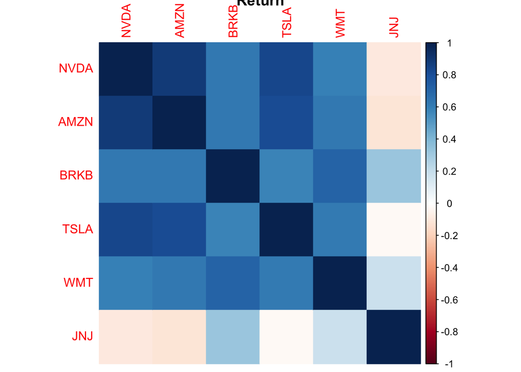

```r
##Returns

merged_returns<-inner_join(nvda_data,amzn_data,by='date',suffix=c('.nvda','.amzn'))|>
                inner_join(brkb_data,by="date",suffix=c(".amzn",".brkb"))|>
                inner_join(tsla_data,by='date',suffix=c(".brkb", ".tsla"))|>
                inner_join(wmt_data,by='date',suffix=c(".tsla", ".wmt"))|>
                inner_join(jnj_data,by='date',suffix=c(".wmt",".jnj"))|>
                select(date,returns.nvda,returns.amzn,returns.brkb,returns.tsla,returns.wmt,
                       returns.jnj)|>
                rename(NVDA=returns.nvda,AMZN=returns.amzn,BRKB=returns.brkb,TSLA=returns.tsla,
                       WMT=returns.wmt,JNJ=returns.jnj)
returns_correlations <- merged_returns|>select(-date)|>cor(use="complete.obs")
returns_corr_heatmap<-returns_correlations|>corrplot(method='color',main="Return")
```

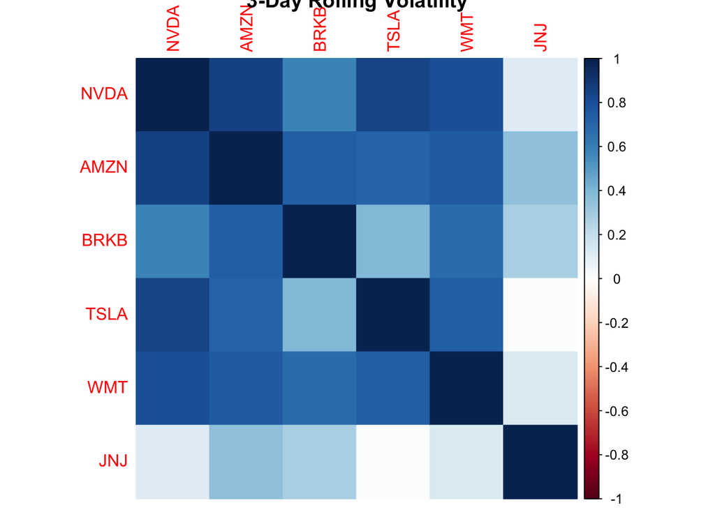

```r
##3-Day Rolling Volatilities
merged_rolling_volatilities<-inner_join(nvda_data,amzn_data,by='date',suffix=c('.nvda','.amzn'))|>
                             inner_join(brkb_data,by="date",suffix=c(".amzn",".brkb"))|>
                             inner_join(tsla_data,by='date',suffix=c(".brkb", ".tsla"))|>
                             inner_join(wmt_data,by='date',suffix=c(".tsla", ".wmt"))|>
                             inner_join(jnj_data,by='date',suffix=c(".wmt",".jnj"))|>
                             select(date,three_day_rolling_volatility.nvda,three_day_rolling_volatility.amzn,
                                    three_day_rolling_volatility.brkb,three_day_rolling_volatility.tsla,
                                    three_day_rolling_volatility.wmt,three_day_rolling_volatility.jnj)|>
                             rename(NVDA=three_day_rolling_volatility.nvda,
                                    AMZN=three_day_rolling_volatility.amzn,
                                    BRKB=three_day_rolling_volatility.brkb,
                                    TSLA=three_day_rolling_volatility.tsla,
                                    WMT=three_day_rolling_volatility.wmt,JNJ=three_day_rolling_volatility.jnj)
rolling_volatilities_correlations <- merged_rolling_volatilities|>select(-date)|>cor(use="complete.obs")
rolling_volatilities_corr_heatmap<-rolling_volatilities_correlations|>corrplot(method='color',
                                                                               main="3-Day Rolling Volatility")
```

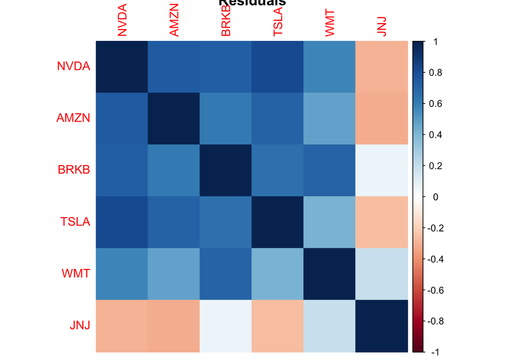

```r
##Residuals
merged_residuals<-inner_join(nvda_data,amzn_data,by='date',suffix=c('.nvda','.amzn'))|>
                  inner_join(brkb_data,by="date",suffix=c(".amzn",".brkb"))|>
                  inner_join(tsla_data,by='date',suffix=c(".brkb", ".tsla"))|>
                  inner_join(wmt_data,by='date',suffix=c(".tsla", ".wmt"))|>
                  inner_join(jnj_data,by='date',suffix=c(".wmt",".jnj"))|>
                  select(date,residual_decomp.nvda,residual_decomp.amzn,residual_decomp.brkb,
                         residual_decomp.tsla,residual_decomp.wmt,residual_decomp.jnj)|>
                  rename(NVDA=residual_decomp.nvda,AMZN=residual_decomp.amzn,
                         BRKB=residual_decomp.brkb,TSLA=residual_decomp.tsla,
                         WMT=residual_decomp.wmt,JNJ=residual_decomp.jnj)
residuals_correlations <- merged_residuals|>select(-date)|>cor(use="complete.obs")
residuals_corr_heatmap<-residuals_correlations|>corrplot(method='color',main="Residuals")
```

## Analysis of Correlation Heatmaps

Amongst all heatmaps, it is clear that Johnson & Johnson has very weak correlations with all other stocks in all variables. This phenomenon further solidifies the previous observations, suggesting that Johnson & Johnson is less vulnerable to economic uncertainties regarding tariffs. Furthermore, this may also imply that the health care sector is less vulnerable to those uncertainties. Nvidia, Walmart, and Amazon all seem to have moderate to strong correlations in 3-day rolling volatility, while Tesla and Berkshire Hathaway have a weaker correlation. Given the heatmaps above, excluding the health care sector, all other GICS sectors exhibit high pairwise correlations during periods of tariff-related economic uncertainty.

## Boxplots

Boxplots showing the distrubution of returns, 3-day rolling volatilities, and residuals.

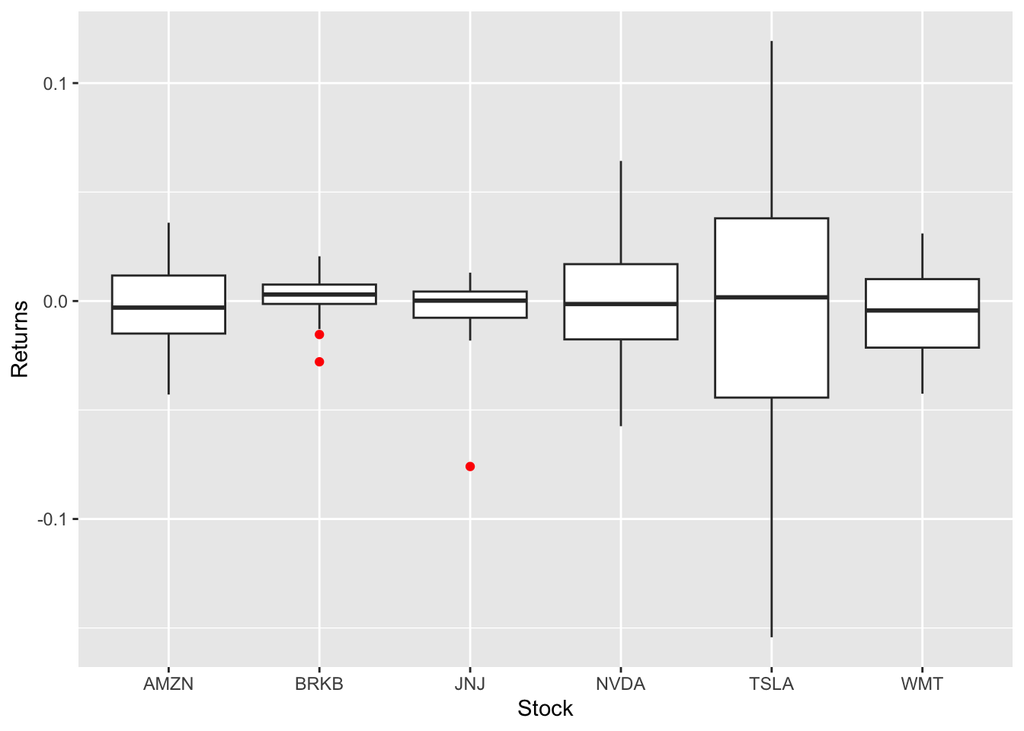

```r
##Returns

returns<-merged_returns|>select(-date)|>pivot_longer (cols=everything(),names_to="Stock",values_to="Returns")
returns_boxplot<-returns|>ggplot(aes(x=Stock,y=Returns))+geom_boxplot(outliers=TRUE,outlier.colour="red",
                                                                      na.rm=TRUE)+labs(x="Stock",y="Returns")
returns_pre<-merged_returns|>filter(date>="2025-03-02",date<="2025-04-01")|>select(-date)|>
                             pivot_longer(cols=everything() ,names_to="Stock",values_to="Returns")
returns_pre_boxplot<-returns_pre|>ggplot(aes(x=Stock,y=Returns))+geom_boxplot(outliers=TRUE,outlier.colour="red",
                                                                              na.rm=TRUE) +
                                  labs(x="Stock",y="Returns")
returns_post<-merged_returns|>filter(date>="2025-04-03",date<="2025-05-02")|>select(-date)|>
                              pivot_longer(cols=everything(),names_to="Stock",values_to="Returns")
returns_post_boxplot<-returns_post|>ggplot(aes(x=Stock,y=Returns))+geom_boxplot(outliers=TRUE,outlier.colour="red",
                                                                                na.rm=TRUE) +
                                    labs(x="Stock",y="Returns")

##3-Day Rolling Volatilities

rolling_volatilities<-merged_rolling_volatilities|>
                      select(-date)|>
                      pivot_longer(cols=everything(),names_to="Stock",values_to="Three_Day_Rolling_Volatility")
rolling_volatilities_boxplot<-rolling_volatilities|>
                              ggplot(aes(x=Stock,y=Three_Day_Rolling_Volatility)) +
                              geom_boxplot(outliers=TRUE,outlier.colour="red",na.rm=TRUE) +
                              labs(x="Stock",y="3-Day Rolling Volatility")
rolling_volatilities_pre<-merged_rolling_volatilities|>
                          filter(date>="2025-03-02",date<="2025-04-01")|>
                          select(-date)|>
                          pivot_longer(cols=everything(),names_to="Stock",values_to="Three_Day_Rolling_Volatility")
rolling_volatilities_pre_boxplot<-rolling_volatilities_pre|>
                                  ggplot(aes(x=Stock,y=Three_Day_Rolling_Volatility)) +
                                  geom_boxplot(outliers=TRUE,outlier.colour="red",na.rm=TRUE) +
                                  labs(x="Stock",y="3-Day Rolling Volatility")
rolling_volatilities_post<-merged_rolling_volatilities|>
                           filter(date>="2025-04-03",date<="2025-05-02")|>
                           select(-date)|>
                           pivot_longer(cols=everything(),names_to="Stock",values_to="Three_Day_Rolling_Volatility")
rolling_volatilities_post_boxplot<-rolling_volatilities_post|>
                                   ggplot(aes(x=Stock,y=Three_Day_Rolling_Volatility)) +
                                   geom_boxplot(outliers=TRUE,outlier.colour="red",na.rm=TRUE) +
                                   labs(x="Stock",y="3-Day Rolling Volatility")

##Residuals

residuals<-merged_residuals|>select(-date)|>pivot_longer(cols=everything(),names_to="Stock",values_to="Residuals")
residuals_boxplot<-residuals|>ggplot(aes(x=Stock,y=Residuals)) +
                              geom_boxplot(outliers=TRUE,outlier.colour="red",na.rm=TRUE)+labs(x="Stock",y="Residuals")
residuals_pre<-merged_residuals|>filter(date>="2025-03-02",date<="2025-04-01")|>
                                 select(-date)|>
                                 pivot_longer(cols=everything(),names_to="Stock",values_to="Residuals")
residuals_pre_boxplot<-residuals_pre|>ggplot(aes(x=Stock,y=Residuals)) +
                                      geom_boxplot(outliers=TRUE,outlier.colour="red",na.rm=TRUE) +
                                      labs(x="Stock",y="Residuals")
residuals_post<-merged_residuals|>filter(date>="2025-04-03",date<="2025-05-02")|>
                                  select(-date)|>
                                  pivot_longer(cols=everything(),names_to="Stock",values_to="Residuals")
residuals_post_boxplot<-residuals_post|>ggplot(aes(x=Stock,y=Residuals)) +
                                        geom_boxplot(outliers=TRUE,outlier.colour="red",na.rm=TRUE) +
                                        labs(x="Stock",y="Residuals")
returns_pre_boxplot
```

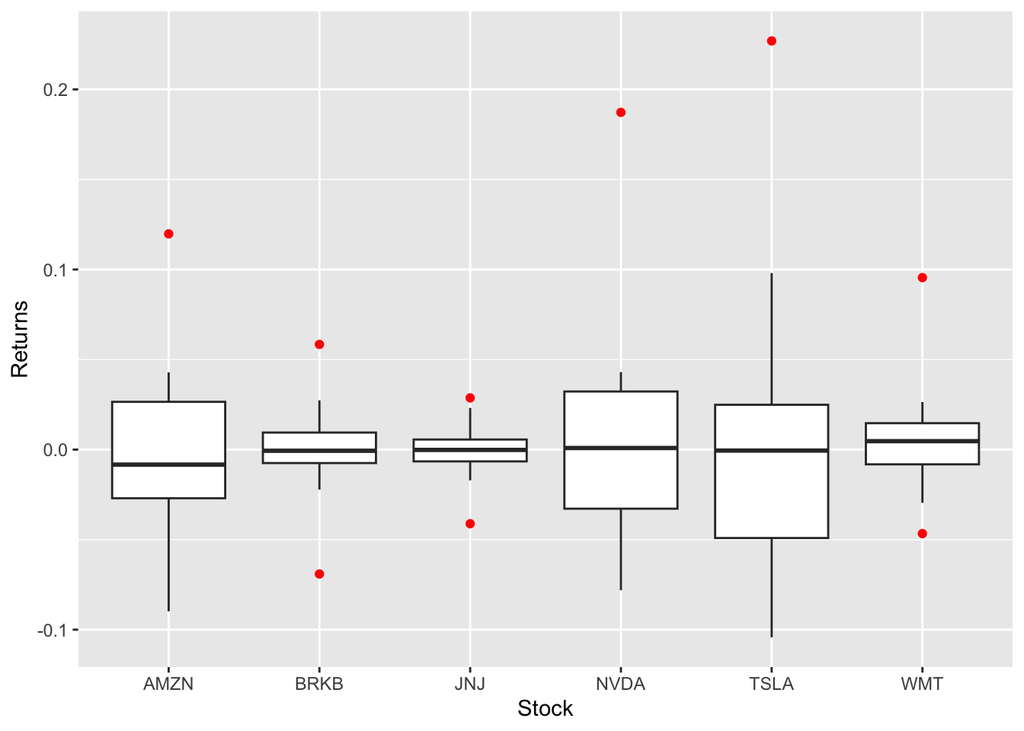

```r
returns_post_boxplot
```

## Summary Statistics

Summary statistics tables included in addition to the boxplots to have a better sense of exact figures

```r
##Returns
returns_summary<-returns|>group_by(Stock)|>summarise(median=median(Returns,na.rm=TRUE),
                                                     Q1=quantile(Returns,.25,na.rm=TRUE),
                                                     Q3=quantile(Returns,.75,na.rm=TRUE),
                                                     min=min(Returns,na.rm=TRUE),
                                                     max=max(Returns,na.rm=TRUE),
                                                     IQR=IQR(Returns,na.rm=TRUE),
                                                     range=max-min)

returns_summary_pre<-returns_pre|>group_by(Stock)|>summarise(median=median(Returns,na.rm=TRUE),
                                                             Q1=quantile(Returns,.25,na.rm=TRUE),
                                                             Q3=quantile(Returns,.75,na.rm=TRUE),
                                                             min=min(Returns,na.rm=TRUE),
                                                             max=max(Returns,na.rm=TRUE),
                                                             IQR=IQR(Returns,na.rm=TRUE),
                                                             range=max-min)

returns_summary_post<-returns_post|>group_by(Stock)|>summarise(median=median(Returns,na.rm=TRUE),
                                                               Q1=quantile(Returns,.25,na.rm=TRUE),
                                                               Q3=quantile(Returns,.75,na.rm=TRUE),
                                                               min=min(Returns,na.rm=TRUE),
                                                               max=max(Returns,na.rm=TRUE),
                                                               IQR=IQR(Returns,na.rm=TRUE),
                                                               range=max-min)
returns_summary_pre
```

```
## # A tibble: 6 × 8
##   Stock    median       Q1      Q3     min    max     IQR  range
##   <chr>     <dbl>    <dbl>   <dbl>   <dbl>  <dbl>   <dbl>  <dbl>
## 1 AMZN  -0.00302  -0.0149  0.0117  -0.0429 0.0359 0.0266  0.0788
## 2 BRKB   0.00299  -0.00132 0.00755 -0.0279 0.0205 0.00887 0.0484
## 3 JNJ    0.000184 -0.00767 0.00435 -0.0759 0.0130 0.0120  0.0889
## 4 NVDA  -0.00138  -0.0176  0.0169  -0.0574 0.0643 0.0345  0.122
## 5 TSLA   0.00170  -0.0443  0.0379  -0.154  0.119  0.0822  0.274
## 6 WMT   -0.00433  -0.0214  0.0101  -0.0425 0.0310 0.0314  0.0735
```

```r
returns_summary_post
```

```
## # A tibble: 6 × 8
##   Stock    median       Q1      Q3     min    max    IQR  range
##   <chr>     <dbl>    <dbl>   <dbl>   <dbl>  <dbl>  <dbl>  <dbl>
## 1 AMZN  -0.00835  -0.0270  0.0265  -0.0898 0.120  0.0535 0.210
## 2 BRKB  -0.000658 -0.00749 0.00946 -0.0691 0.0584 0.0169 0.127
## 3 JNJ   -0.000186 -0.00655 0.00558 -0.0412 0.0287 0.0121 0.0699
## 4 NVDA   0.000875 -0.0328  0.0323  -0.0781 0.187  0.0651 0.265
## 5 TSLA  -0.000551 -0.0491  0.0249  -0.104  0.227  0.0740 0.331
## 6 WMT    0.00467  -0.00819 0.0146  -0.0466 0.0955 0.0228 0.142
```

```r
##Residuals
residuals_summary<-residuals|>group_by(Stock)|>summarise(median=median(Residuals),
                                                         Q1=quantile(Residuals,.25,na.rm=TRUE),
                                                         Q3=quantile(Residuals,.75,na.rm=TRUE),
                                                         min=min(Residuals),
                                                         max=max(Residuals),
                                                         IQR=Q3-Q1,
                                                         range=max-min)

residuals_summary_pre<-residuals_pre|>group_by(Stock)|>summarise(median=median(Residuals),
                                                                 Q1=quantile(Residuals,.25,na.rm=TRUE),
                                                                 Q3=quantile(Residuals,.75,na.rm=TRUE),
                                                                 min=min(Residuals),max=max(Residuals),
                                                                 IQR=Q3-Q1,
                                                                 range=max-min)

residuals_summary_post<-residuals_post|>group_by(Stock)|>summarise(median=median(Residuals),
                                                                   Q1=quantile(Residuals,.25,na.rm=TRUE),
                                                                   Q3=quantile(Residuals,.75,na.rm=TRUE),
                                                                   min=min(Residuals),
                                                                   max=max(Residuals),
                                                                   IQR=Q3-Q1,
                                                                   range=max-min)
residuals_summary_pre
```

```
## # A tibble: 6 × 8
##   Stock median     Q1    Q3    min   max   IQR range
##   <chr>  <dbl>  <dbl> <dbl>  <dbl> <dbl> <dbl> <dbl>
## 1 AMZN  -0.393 -1.38  1.47   -4.72  5.30  2.86 10.0
## 2 BRKB  -0.623 -3.55  2.48   -7.41  7.64  6.03 15.0
## 3 JNJ   -0.135 -1.02  0.999  -4.56  7.12  2.02 11.7
## 4 NVDA  -0.155 -2.19  2.32   -7.48  5.82  4.51 13.3
## 5 TSLA  -0.287 -6.55  5.01  -21.8  16.1  11.6  37.9
## 6 WMT    0.139 -0.532 1.46   -3.58  2.43  2.00  6.01
```

```r
residuals_summary_post
```

```
## # A tibble: 6 × 8
##   Stock  median      Q1    Q3    min   max   IQR range
##   <chr>   <dbl>   <dbl> <dbl>  <dbl> <dbl> <dbl> <dbl>
## 1 AMZN  -1.17    -2.98  1.49   -7.74 10.4   4.47 18.1
## 2 BRKB   1.25    -5.34  6.03  -22.2  11.6  11.4  33.8
## 3 JNJ   -0.0785  -1.17  0.738  -3.28  4.06  1.91  7.34
## 4 NVDA  -0.328   -4.99  2.59   -9.24  9.12  7.58 18.4
## 5 TSLA  -0.0930 -11.1   6.92  -25.5  25.9  18.0  51.4
## 6 WMT    0.188   -0.870 1.09   -6.83  3.87  1.96 10.7
```

```r
##3-Day Rolling Volatility
rolling_volatilities_summary<-rolling_volatilities|>
                              group_by(Stock)|>
                              summarise(median=median(Three_Day_Rolling_Volatility,na.rm=TRUE),
                                        Q1=quantile(Three_Day_Rolling_Volatility,.25,na.rm=TRUE),
                                        Q3=quantile(Three_Day_Rolling_Volatility,.75,na.rm=TRUE),
                                        min=min(Three_Day_Rolling_Volatility,na.rm=TRUE),
                                        max=max(Three_Day_Rolling_Volatility,na.rm=TRUE),
                                        IQR=Q3-Q1,
                                        range=max-min)

rolling_volatilities_summary_pre<-rolling_volatilities_pre|>
                                  group_by(Stock)|>
                                  summarise(median=median(Three_Day_Rolling_Volatility,na.rm=TRUE),
                                            Q1=quantile(Three_Day_Rolling_Volatility,.25,na.rm=TRUE),
                                            Q3=quantile(Three_Day_Rolling_Volatility,.75,na.rm=TRUE),
                                            min=min(Three_Day_Rolling_Volatility,na.rm=TRUE),
                                            max=max(Three_Day_Rolling_Volatility,na.rm=TRUE),
                                            IQR=Q3-Q1,
                                            range=max-min)

rolling_volatilities_summary_post<-rolling_volatilities_post|>
                                   group_by(Stock)|>
                                   summarise(median=median(Three_Day_Rolling_Volatility,na.rm=TRUE),
                                             Q1=quantile(Three_Day_Rolling_Volatility,.25,na.rm=TRUE),
                                             Q3=quantile(Three_Day_Rolling_Volatility,.75,na.rm=TRUE),
                                             min=min(Three_Day_Rolling_Volatility),
                                             max=max(Three_Day_Rolling_Volatility),
                                             IQR=Q3-Q1,
                                             range=max-min)
rolling_volatilities_summary_pre
```

```
## # A tibble: 6 × 8
##   Stock  median      Q1      Q3      min    max     IQR  range
##   <chr>   <dbl>   <dbl>   <dbl>    <dbl>  <dbl>   <dbl>  <dbl>
## 1 AMZN  0.0202  0.0168  0.0238  0.00858  0.0296 0.00705 0.0210
## 2 BRKB  0.0105  0.00360 0.0117  0.00128  0.0235 0.00812 0.0222
## 3 JNJ   0.00797 0.00450 0.00959 0.000880 0.0488 0.00509 0.0480
## 4 NVDA  0.0309  0.0213  0.0416  0.00398  0.0578 0.0203  0.0538
## 5 TSLA  0.0499  0.0437  0.0570  0.0195   0.123  0.0133  0.104
## 6 WMT   0.0189  0.0149  0.0216  0.00619  0.0265 0.00673 0.0203
```

```r
rolling_volatilities_summary_post
```

```
## # A tibble: 6 × 8
##   Stock median      Q1     Q3     min    max     IQR  range
##   <chr>  <dbl>   <dbl>  <dbl>   <dbl>  <dbl>   <dbl>  <dbl>
## 1 AMZN  0.0289 0.0113  0.0557 0.00524 0.0925 0.0444  0.0873
## 2 BRKB  0.0144 0.00886 0.0343 0.00437 0.0401 0.0254  0.0357
## 3 JNJ   0.0127 0.00980 0.0181 0.00121 0.0566 0.00833 0.0554
## 4 NVDA  0.0424 0.0192  0.0519 0.00346 0.131  0.0326  0.128
## 5 TSLA  0.0411 0.0307  0.0590 0.00409 0.167  0.0284  0.162
## 6 WMT   0.0209 0.00855 0.0274 0.00554 0.0620 0.0188  0.0565
```

## Analysis of Boxplot Statistics

Except Johnson & Johnson, all stocks experienced an increase in the range of returns and residuals after Liberation Day. A higher range indicates higher variability in price movement, as expected by the influence of economic uncertainty on market valuations. With regards to residual values, the economic uncertainties can cause markets to have random fluctuations in stock prices, making them less predictable by the trend decomposition. Given that 3-day rolling volatility increased for these same stocks as well, stock prices fluctuate more after Liberation Day. Though Johnson & Johnson also had an increase in range for 3-day rolling volatility after Liberation Day, its increase was the smallest among all stocks analyzed. Since its returns are decreasing in variability, any sharp changes in returns were limited in duration, and prices stabilized faster than the other stocks, allowing for companies in the health care sector to be less prone to such market noise brought by Liberation Day tariffs.